# Chapter 6: Linear Model Selection and Regularization

Matt Kosko

5/19/2018

In this exercise, we will generate simulated data, and will then use this data to perform best subset selection.

1. Use the `rnorm()` function to generate a predictor X of length $n = 100$, as well as a noise vector $\epsilon$ of length $n = 100$.

```r
set.seed(123)
x <- rnorm(100)
eps <- rnorm(100)
```

2. Generate a response vector $Y$ of length $n = 100$ according to the model
   $$Y = \beta_0 +\beta_1X +\beta_2X^2 +\beta_3X^3 +\epsilon,$$

where $\beta_0$, $\beta_1$, $\beta_2$, and $\beta_3$ are constants of your choice.

```r
y <- 1 + x + 2*x^2 + 3*x^3 + eps
```

3. Use the `regsubsets()` function to perform best subset selection in order to choose the best model containing the predictors $X$, $X^2$, $\ldots$, $X^{10}$. What is the best model obtained according to $C_p$, BIC, and adjusted $R^2$? Show some plots to provide evidence for your answer, and report the coefficients of the best model obtained. Note you will need to use the `data.frame()` function to create a single data set containing both X and Y.

```r
df <- data.frame(x = x, y = y)
subset_fit <- regsubsets(y ~ poly(x, 10, raw = TRUE), data = df)
sum_subset <- summary(subset_fit)
paste(paste(paste('According to Mallows Cp, the best model is', which.min(sum_subset$cp), sep = ' '), '.', sep = ''), paste('On the basis of BIC, the best model is', which.min(sum_subset$bic), 'and on the basis of adjusted R^2, the best model is', which.max(sum_subset$adjr2), sep = ' '))
```

```
## [1] "According to Mallows Cp, the best model is 3. On the basis of BIC, the best model is 3 and on the basis of adjusted R^2, the best model is 7"
```

```r
paste('The coefficients for the 3rd model are:', paste(names(coef(subset_fit, 3)), collapse = ', '))
```

```
## [1] "The coefficients for the 3rd model are: (Intercept), poly(x, 10, raw = TRUE)1, poly(x, 10, raw = TRUE)2, poly(x, 10, raw = TRUE)3"
```

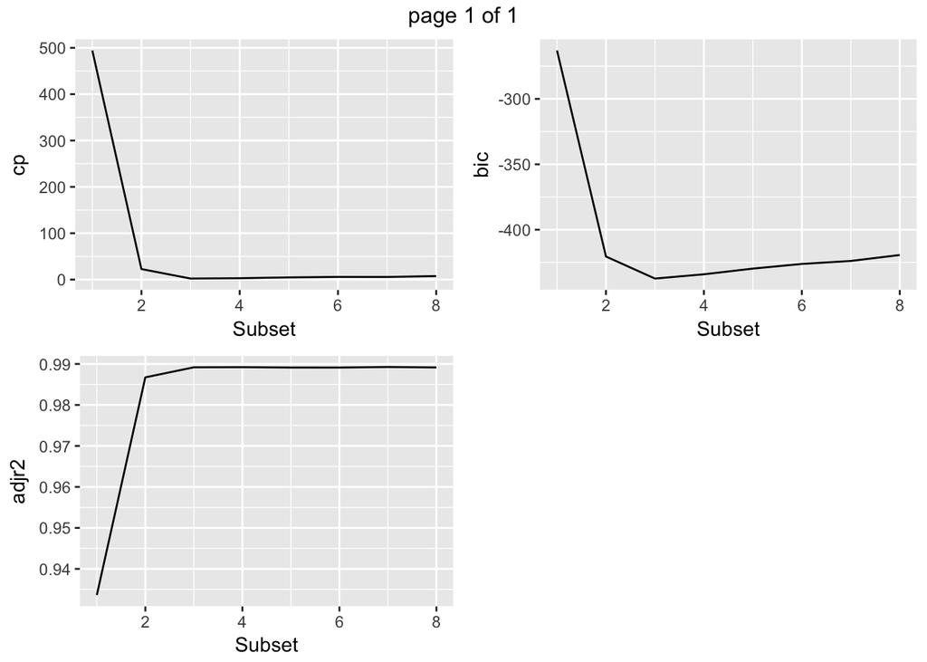

```r
sums <- data.frame(cp = sum_subset$cp, adjr2 = sum_subset$adjr2, bic = sum_subset$bic)
make_subset_plots <- function(data, pred, x_lab, color = NULL, x = NULL){
  if (missing(color)) {
    ggplot(data) + geom_line(aes_(x = as.numeric(row.names(data)), y = as.name(pred))) + xlab(x_lab)
  } else {
    ggplot(data) + geom_line(aes_(x = as.name(x), y = as.name(pred), color = as.name(color))) + xlab(x_lab)
  }

}
marrangeGrob(map(names(sums), make_subset_plots, data = sums, x_lab = 'Subset'), nrow = 2, ncol = 2)
```

4. Repeat (c), using forward stepwise selection and also using backwards stepwise selection. How does your answer compare to the results in (c)?

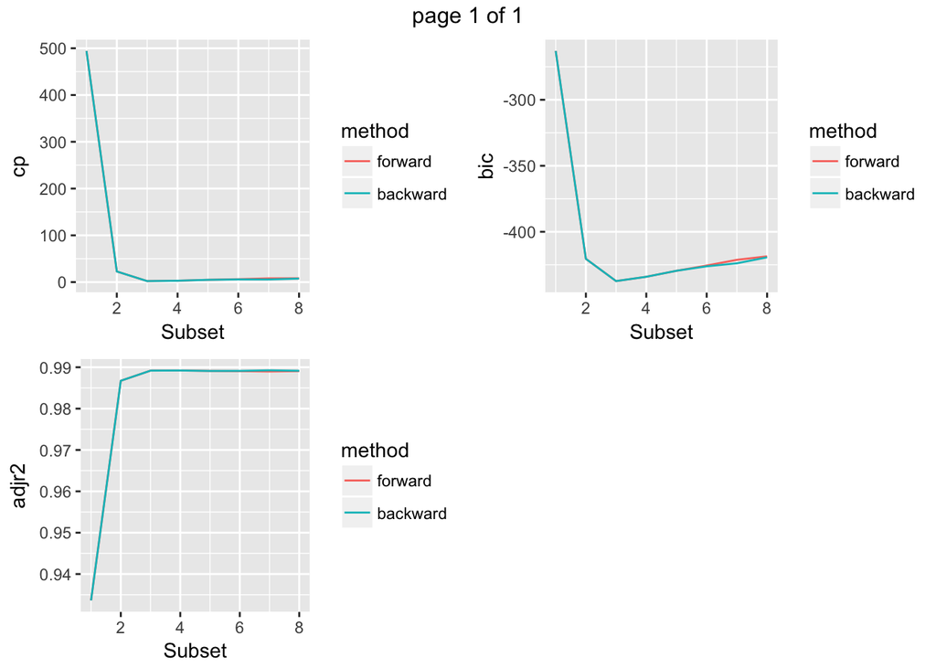

```r
selection <- function(data, method){
  regsubsets(y~poly(x, 10, raw = TRUE), data = data, method = method)
}
create_df <- function(data, method){
  fit <- selection(data, method = method)
  sum_subset <- summary(fit)
  data.frame(cp = sum_subset$cp, adjr2 = sum_subset$adjr2, bic = sum_subset$bic, method = method, x = 1:length(sum_subset$cp))
}
methods <- do.call('rbind', map(c('forward','backward'), create_df, data = df))
marrangeGrob(map(c('cp', 'adjr2', 'bic'), make_subset_plots, data = methods, x_lab = 'Subset', color = 'method', x = 'x'), nrow = 2, ncol = 2)
```

The restuls are similar.

5. Now fit a lasso model to the simulated data, again using $X$,$X^2$, $\ldots$, $X^{10}$ as predictors. Use cross-validation to select the optimal value of $\lambda$. Create plots of the cross-validation error as a function of $\lambda$. Report the resulting coefficient estimates, and discuss the results obtained.

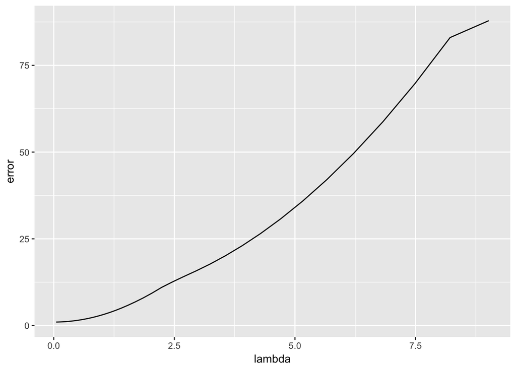

```r
data <- data.frame(y, poly(x, 10, raw = TRUE))
X <- model.matrix(y ~., data)[, -1]
cv.out <- cv.glmnet(X, y, alpha = 1)
lasso.out <- glmnet(X, y, alpha = 1)
preds <- predict(lasso.out, type = 'coefficients', s = cv.out$lambda.1se)
lasso <- data.frame(lambda = cv.out$lambda, error = cv.out$cvm)
ggplot(lasso, aes(x = lambda, y = error)) + geom_line()
```

6. Now generate a response vector Y according to the model $Y = \beta_0 + \beta_7X^7 + \epsilon$, and perform best subset selection and the lasso. Discuss the results obtained.

```r
y <- 1 + 7*x^7 + eps
df <- data.frame(x = x, y = y)
subset_fit <- regsubsets(y ~ poly(x, 10, raw = TRUE), data = df)
sum_subset <- summary(subset_fit)
paste(paste(paste('According to Mallows Cp, the best model is', which.min(sum_subset$cp), sep = ' '), '.', sep = ''), paste('On the basis of BIC, the best model is', which.min(sum_subset$bic), 'and on the basis of adjusted R^2, the best model is', which.max(sum_subset$adjr2), sep = ' '))
```

```
## [1] "According to Mallows Cp, the best model is 1. On the basis of BIC, the best model is 1 and on the basis of adjusted R^2, the best model is 6"
```

```r
paste('The coefficients for the 8th model are:', paste(names(coef(subset_fit, 1)), collapse = ', '))
```

```
## [1] "The coefficients for the 8th model are: (Intercept), poly(x, 10, raw = TRUE)7"
```

Perfect! Now using the lasso instead,

```r
data <- data.frame(y, poly(x, 10, raw = TRUE))
X <- model.matrix(y ~., data)[, -1]
#grid <- 10^seq(10,-2, length=100)
cv.out <- cv.glmnet(X, y, alpha = 1)#, lambda = grid)
lasso.out <- glmnet(X, y, alpha = 1)#, lambda = grid)
preds <- predict(lasso.out, type = 'coefficients', s = cv.out$lambda.1se)
preds
```

```
## 11 x 1 sparse Matrix of class "dgCMatrix"
##                    1
## (Intercept) 1.621601
## X1          .
## X2          .
## X3          .
## X4          .
## X5          .
## X6          .
## X7          6.729969
## X8          .
## X9          .
## X10         .
```

Great!

9. In this exercise, we will predict the number of applications received using the other variables in the College data set.
1. Split the data set into a training set and a test set.

```r
set.seed(123)
train <- sample(1:(nrow(College)/2))
```

2. Fit a linear model using least squares on the training set, and report the test error obtained.

```r
lm.out <- lm(Apps ~., data = College, subset = train)
predictions <- predict(lm.out, newdata = College[-train, ])
mean((College[-train, 'Apps'] - predictions)^2)
```

```
## [1] 1714500
```

3. Fit a ridge regression model on the training set, with $\lambda$ chosen by cross-validation. Report the test error obtained.

```r
regularization <- function(data, alpha, preds, dep, training){
  formula1 <- paste(dep, '~', paste(preds, collapse = ' + '), sep = ' ')
  x <- model.matrix(object = as.formula(formula1), data = data)[, -1]
  y <- College[ , dep]
  cv.out <- cv.glmnet(x[train, ], y[train])
  best_lam <- cv.out$lambda.min
  out <- glmnet(x[train, ], y[train], alpha = alpha)
  pred <- predict(out, s = best_lam, newx = x[-train, ])
  mean((pred - y[-train])^2)
}

regularization(data = College, alpha = 0, preds = names(College)[names(College)!='Apps'], dep = 'Apps', training = train)
```

```
## [1] 2657435
```

4. Fit a lasso model on the training set, with $\lambda$ chosen by cross-validation. Report the test error obtained, along with the number of non-zero coefficient estimates.

```r
regularization(data = College, alpha = 1, preds = names(College)[names(College)!='Apps'], dep = 'Apps', training = train)
```

```
## [1] 1742633
```

5. Fit a PCR model on the training set, with $M$ chosen by cross-validation. Report the test error obtained, along with the value of $M$ selected by cross-validation.

```r
get_test_mse_p <- function(data, dep, preds, FUN, training, validation, scale = TRUE){
  form <- paste(dep, '~', paste(preds, collapse = ' + '), sep = ' ')
  formula <- as.formula(form)
  model.fit <- FUN(formula = formula, data = data, subset = training,
                   validation = validation, scale = scale)
  min_mse <- (which.min(MSEP(model.fit)$val[2, 1, ]) - 1)
  predictions <- predict(model.fit, newdata = data[-training, ], ncomp = min_mse)
  c(MSE = mean((data[-training, dep] - predictions)^2), comps = min_mse)
}
get_test_mse_p(data = College, dep = 'Apps', preds = names(College)[names(College)!= 'Apps'], pcr, training = train, validation = 'CV')
```

```
##            MSE comps.17 comps
##        1714500             17
```

6. Fit a PLS model on the training set, with M chosen by cross- validation. Report the test error obtained, along with the value of M selected by cross-validation.

```r
get_test_mse_p(data = College, dep = 'Apps', preds = names(College)[names(College)!= 'Apps'], plsr, training = train, validation = 'CV')
```

```
##            MSE comps.12 comps
##        1715885             12
```

7. Comment on the results obtained. How accurately can we predict the number of college applications received? Is there much difference among the test errors resulting from these five approaches?

10. We have seen that as the number of features used in a model increases, the training error will necessarily decrease, but the test error may not. We will now explore this in a simulated data set.
1. Generate a data set with $p = 20$ features, $n = 1000$ observations, and an associated quantitative response vector generated according to the model $Y = X\beta+\epsilon$, where $\beta$ has some elements that are exactly equal to zero.

```r
x <- matrix(rnorm(20000), nrow = 1000, ncol = 20)
eps <- rnorm(1000)
beta <- sample(0:10, size = 20, replace = TRUE, prob = c(0.3, rep(0.7/10, 10)))
y <- x %*% beta + eps
beta
```

```
##  [1] 0 9 6 0 0 0 0 9 3 4 3 0 4 3 8 6 6 8 5 7
```

2. Split your dataset into a training set containing 100 observations and a test set containing 900 observations.

```r
set.seed(231)
train <- sample(1:1000, 100)
```

3. Perform best subset selection on the training set, and plot the training set MSE associated with the best model of each size.

```r
X <- model.matrix(y ~ x)[, -1]
best.out <- regsubsets(X[train, ], y[train], nvmax = 21, intercept = FALSE)
get_train_mse <- function(mat, dep, model, training, i){
  coefs <- coef(model, id = i)
  pred <- mat[training, names(coefs)] %*% as.matrix(coefs)
  mean((pred-dep[training])^2)
}
train_mse <- map_dbl(1:20, get_train_mse, mat = X, dep = y, training = train, model = best.out)
```

4. Plot the test set MSE associated with the best model of each size.

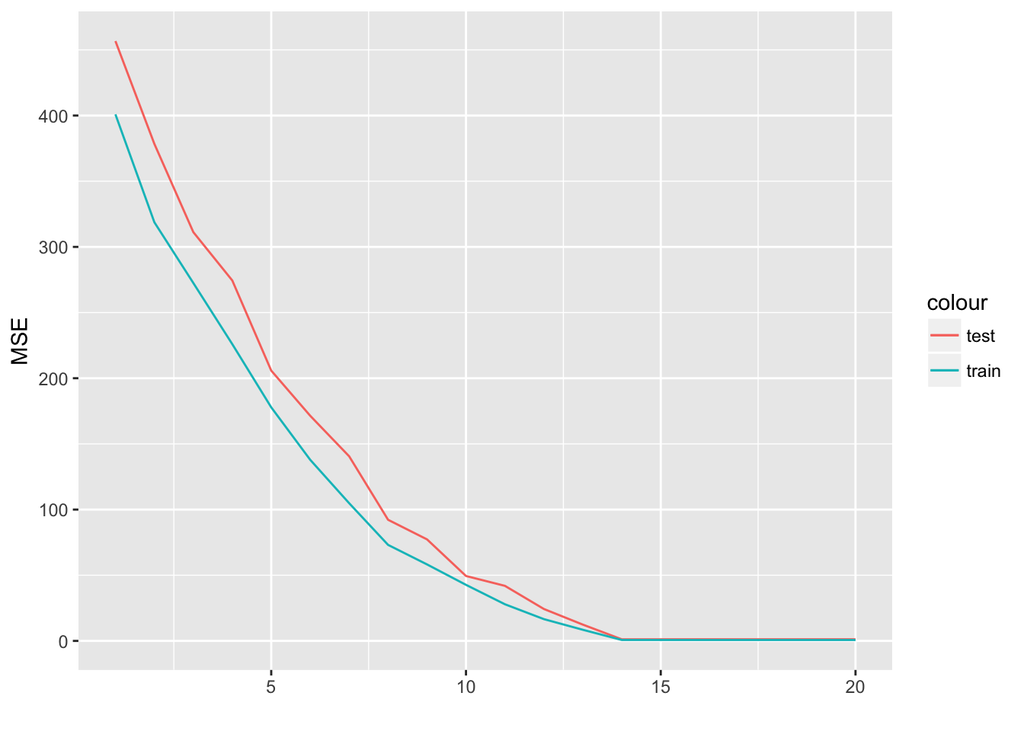

```r
get_test_mse <- function(mat, dep, model, training, i){
  coefs <- coef(model, id = i)
  pred <- mat[-training, names(coefs)] %*% as.matrix(coefs)
  mean((pred-dep[-training])^2)
}
test_mse <- map_dbl(1:20, get_test_mse, mat = X, dep = y, training = train, model = best.out)
df <- data.frame(test = test_mse, train = train_mse)
ggplot(df, aes(x = seq_along(test))) + geom_line(aes(y = test, color = 'test')) +
  geom_line(aes(y = train, color = 'train')) + xlab('') + ylab('MSE')
```

5. For which model size does the test set MSE take on its minimum value? Comment on your results. If it takes on its minimum value for a model containing only an intercept or a model containing all of the features, then play around with the way that you are generating the data in (a) until you come up with a scenario in which the test set MSE is minimized for an intermediate model size.

```r
which.min(test_mse)
```

```
## [1] 14
```

```r
coef(best.out, which.min(test_mse))
```

```
##       x2       x3       x8       x9      x10      x11      x13      x14
## 9.178271 6.002579 8.850756 3.010917 3.934584 3.200541 3.947011 2.909226
##      x15      x16      x17      x18      x19      x20
## 8.087266 5.900221 6.034999 8.101503 5.142870 7.137831
```

6. How does the model at which the test set MSE is minimized compare to the true model used to generate the data? Comment on the coefficient values.

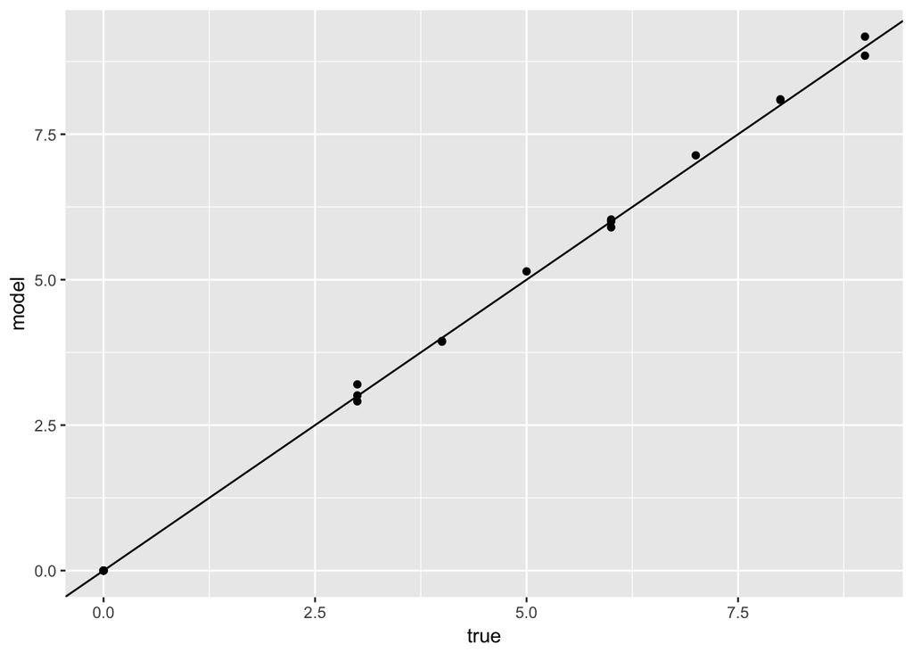

```r
best_coefs <- coef(best.out, id = which.min(test_mse))
best_coefs <- best_coefs[dimnames(X)[[2]]]
names(best_coefs) <- dimnames(X)[[2]]
best_coefs[is.na(best_coefs)] <- 0
df <- data.frame(true = beta, model = best_coefs)
ggplot(df, aes(x = true, y = model)) + geom_point() + geom_abline(slope = 1, intercept = 0)
```

7. Create a plot displaying $\sqrt{\left(\sum_{j=1}^p (\beta_j -\hat{\beta_j^r}\right)}$ for a range of values of $r$, where $\hat{\beta_j^r}$ is the $j$th coefficient estimate for the best model containing $r$ coefficients. Comment on what you observe. How does this compare to the test MSE plot from (d)?

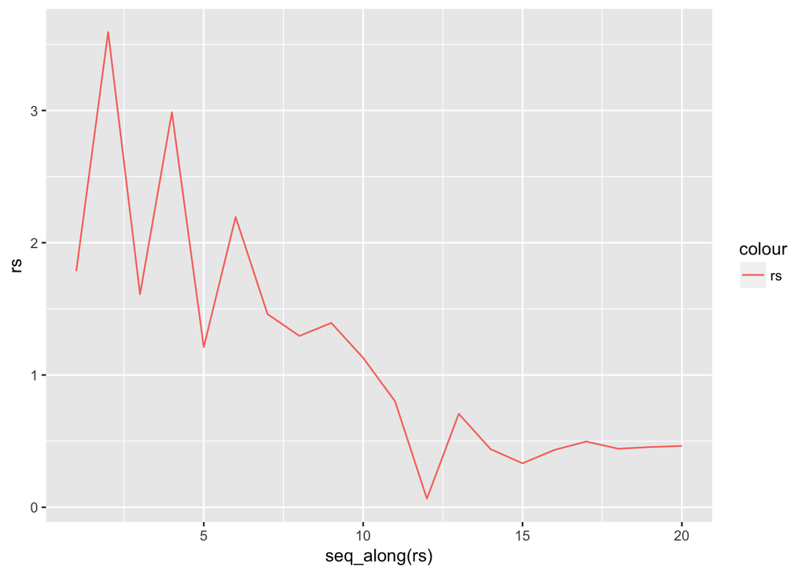

```r
names(beta) <- dimnames(X)[[2]]
diffs <- function(model, i){
  coefs <- coef(model, id = i)
  sqrt(sum(beta[names(coefs)]- coefs)^2)
}
rs <- map_dbl(1:20, diffs, model = best.out)
df <- cbind(df, rs = rs)
ggplot(df, aes(x = seq_along(rs))) + geom_line(aes(y = rs, color = 'rs'))
```